The raw code for this IPython notebook is hidden for easier reading. To toggle on/off the raw code, click here.

# The Carpentries: Programmatic Assessment Report

## January 1, 2012 through March 31, 2018

#### Authors: Maneesha Sane, Erin Becker

**Do we need "about the Carpentries" boilerplate here? (including history of DC as a newer program)**

We began systematically recording data for our workshops in 2012. We used this data to investigate how have The Carpentries have grown over the years including number and geographic reach of our workshops, and learners at these workshops. We also look at our Instructor Training program, including number and geographic reach of instructor training events, number of trainees and their completion rates, and onboarding of new Instructor Trainers.

Data are collected by a team of Workshop Administrators. In Africa, Australia, Canada, New Zealand, and the United Kingdom, Workshop Adminstrators are affiliated with our member institutions and provide in-kind staff time. A full-time Carpentries staff member is the Workshop Administrator for the rest the world.

## Part 1: Workshops

### The Carpentries

**Do we need "what is a workshop" boilerplate here?**

For each workshop, we collected the following data:

| variable | definition |
| --- | --- |
| slug | Unique identifier for each workshop. Takes the form `YYYY-MM-DD-sitename`. |
| start | Start date of the workshop. Takes the form `YYYY-MM-DD`. |
| attendance | Number of learners at the workshop. |
| host_name | Institution that hosted the workshop. |
| country | The two-letter country code for the country in which the workshop was held. |
| workshop_type | Whether this is a Software Carpentry (SWC) or Data Carpentry (DC) workshop. |

The full data set, representing 1332 workshops, can be found in the Programmatic Assessment folder of The Carpentries Assessment repository on GitHub (https://github.com/carpentries/assessment/tree/master/programmatic-assessment).

The data shown here may not account for unreported self-organized workshops. Although The Carpentries attempts to collect data on all workshops run under "The Carpentries" brand, sometimes institutions may run a workshop without reporting it back to The Carpentries staff. Thus, if there has been a shift from more centrally-organized to more self-organized workshops, this may cause an underestimate of our workshop growth. We are working to improve data collection to have more accurate reflections of our scope of work.

This may also reflect a shift to sites running a variation of Carpentries lessons, rather than official full Carpentries workshops. While we've known anecdotally that this happens often, we have not systematically collected any data on when or how Carpentries lessons are used in other contexts.

**Figure (#): Workshops by Carpentry by Year**

This bar chart shows the number of Data Carpentry (DC) and Software Carpentry (SWC) workshops each year. Data for 2018 is a projection. The proportion of workshops in the first quarter of 2017 relative to the full year was applied to actual first quarter data from 2018 to calcuate this projection. Source data can be found in the appendix.

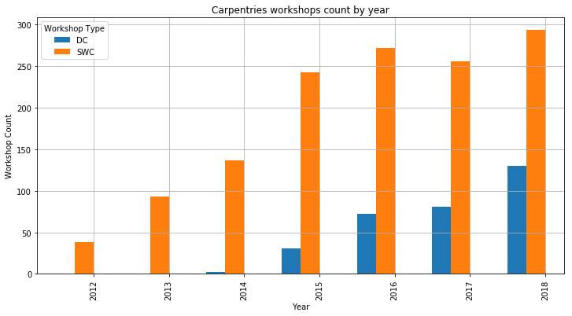

### Geographic reach

In many countries, we have seen a steady increase in the number of workshops run. In several countries though (Australia, New Zealand, Canada), we have seen a decline in the number of workshops run. This may be due to the reasons cited above, including unreported self-organized workshops or an increase in variations on Carpentries workshops. In either case this is a motivation for The Carpentries to improve data collection and methods to understand our scope of work beyond our centrally coordinated workshops.

Decreases in the number of workshops run in some countries may also be accounted for by shifts in our instructor community. Carpentries activity is sustained by our instructors. Some instructors may move to new geographies or to new career phases. Without a larger community in place, these geographies may not have had the capacity to sustain their activity. This is a motivation for The Carpentries to build strong and sustainable communities, with systems that account for individual turnover.

### Figure (#): Countries hosting 10 or more workshops

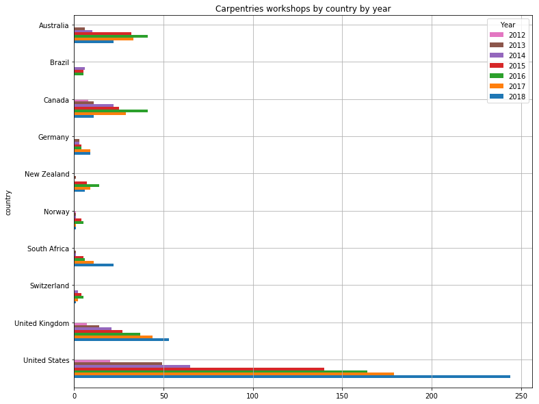

### FIgure (#): Countries hosting first workshop each year

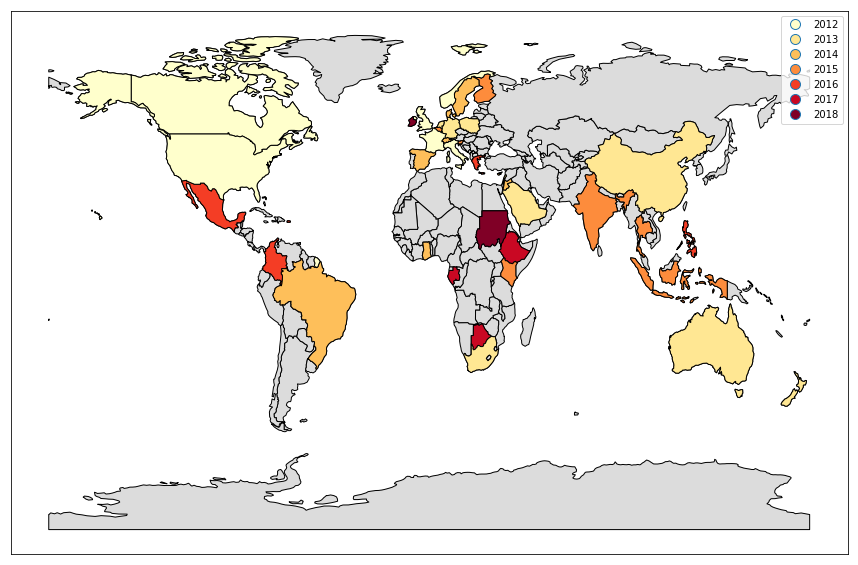

### Figure (#) Number of unique countries hosting a workshop each year

How do we visually represent the total? (from here, need to cast floats as ints for year)

Note table is in appendix

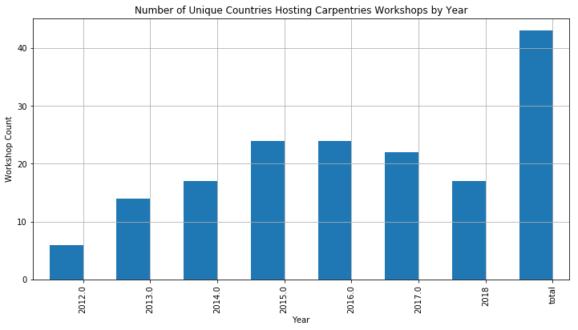

### Workshop Attendance (rename?)

- Intro narrative: In addition to looking at how many workshops we’ve run we look at how many people we’ve impacted.
- Refer to workshops data in gh repo (same as workshops above

### Figure (#) Total attendance by Carpentry by year

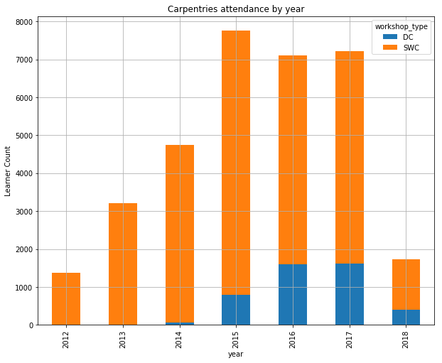

### Figure (#): Class size by year.

Box plot. Same captioning, also include how to read box plot. Note 2018 is acutal, not projected data.

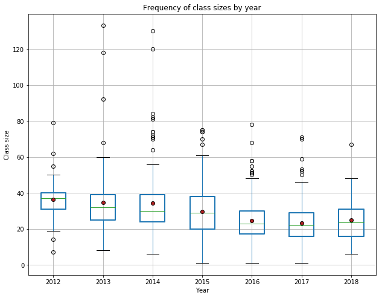

## Appendix

Table numbering will be fixed for final draft

### Table 1: Workshops by Carpentry by Year

This table shows the number of Data Carpentry (DC) and Software Carpentry (SWC) workshops each year. Data for 2018 is a projection. The proportion of workshops in the first quarter of 2017 relative to the full year was applied to actual first quarter data from 2018.

| Workshop Type Year | DC | SWC | total |
| --- | --- | --- | --- |
| 2012 | 0 | 38 | 38 |
| 2013 | 0 | 93 | 93 |
| 2014 | 2 | 137 | 139 |
| 2015 | 31 | 243 | 274 |
| 2016 | 72 | 272 | 344 |
| 2017 | 81 | 256 | 337 |
| 2018 | 130 | 294 | 424 |

### Table 2: All countries hosting a Carpentries workshop

This table shows the number of Data Carpentry (DC) and Software Carpentry (SWC) workshops in each country each year. For 2018, only actual data through March is represented, as most countries' data is too small to make meaningful predicitons.

| start_date country | 2012 | 2013 | 2014 | 2015 | 2016 | 2017 | 2018Q1 | total |
| --- | --- | --- | --- | --- | --- | --- | --- | --- |
| Australia | 0 | 6 | 10 | 32 | 41 | 33 | 6 | 128 |
| Belgium | 0 | 0 | 0 | 1 | 0 | 1 | 0 | 2 |
| Botswana | 0 | 0 | 0 | 0 | 0 | 1 | 0 | 1 |
| Brazil | 0 | 0 | 6 | 5 | 5 | 0 | 0 | 16 |
| Canada | 8 | 11 | 22 | 25 | 41 | 29 | 4 | 140 |
| China | 0 | 1 | 0 | 0 | 0 | 0 | 0 | 1 |
| Colombia | 0 | 0 | 0 | 0 | 1 | 0 | 0 | 1 |
| Cyprus | 0 | 0 | 1 | 0 | 0 | 0 | 0 | 1 |
| Denmark | 0 | 0 | 1 | 0 | 2 | 3 | 1 | 7 |
| Ethiopia | 0 | 0 | 0 | 0 | 0 | 4 | 4 | 8 |
| Finland | 0 | 0 | 0 | 2 | 0 | 0 | 0 | 2 |
| France | 1 | 2 | 0 | 1 | 3 | 0 | 1 | 8 |
| Gabon | 0 | 0 | 0 | 0 | 0 | 1 | 0 | 1 |
| Germany | 0 | 3 | 3 | 4 | 4 | 9 | 2 | 25 |
| Ghana | 0 | 0 | 1 | 0 | 0 | 1 | 0 | 2 |
| Greece | 0 | 0 | 0 | 0 | 1 | 0 | 0 | 1 |
| India | 0 | 0 | 0 | 1 | 0 | 0 | 0 | 1 |
| Indonesia | 0 | 0 | 0 | 1 | 0 | 0 | 0 | 1 |
| Ireland | 0 | 0 | 0 | 0 | 0 | 0 | 1 | 1 |
| Italy | 1 | 0 | 1 | 0 | 2 | 0 | 1 | 5 |
| Jordan | 0 | 0 | 1 | 0 | 0 | 0 | 0 | 1 |
| Kenya | 0 | 0 | 0 | 1 | 1 | 0 | 0 | 2 |
| Korea, Republic of | 0 | 0 | 0 | 4 | 1 | 0 | 0 | 5 |
| Lebanon | 0 | 1 | 0 | 0 | 0 | 0 | 0 | 1 |
| Mauritius | 0 | 0 | 0 | 0 | 0 | 1 | 0 | 1 |
| Mexico | 0 | 0 | 0 | 0 | 1 | 1 | 1 | 3 |
| Netherlands | 0 | 1 | 0 | 3 | 2 | 2 | 0 | 8 |
| New Zealand | 0 | 1 | 0 | 7 | 14 | 9 | 2 | 33 |
| Norway | 1 | 1 | 1 | 4 | 5 | 1 | 1 | 14 |
| Philippines | 0 | 0 | 0 | 0 | 1 | 0 | 0 | 1 |
| Poland | 0 | 1 | 1 | 2 | 4 | 1 | 0 | 9 |
| Puerto Rico | 0 | 0 | 0 | 0 | 1 | 0 | 0 | 1 |
| Saudi Arabia | 0 | 1 | 0 | 0 | 0 | 0 | 0 | 1 |
| Slovenia | 0 | 0 | 0 | 1 | 0 | 0 | 0 | 1 |
| South Africa | 0 | 1 | 1 | 5 | 6 | 11 | 2 | 26 |
| Spain | 0 | 0 | 1 | 1 | 1 | 2 | 0 | 5 |
| Sudan | 0 | 0 | 0 | 0 | 0 | 0 | 1 | 1 |
| Sweden | 0 | 0 | 1 | 1 | 1 | 1 | 2 | 6 |
| Switzerland | 0 | 0 | 2 | 4 | 5 | 2 | 1 | 14 |
| Thailand | 0 | 0 | 0 | 1 | 0 | 1 | 0 | 2 |
| United Kingdom | 7 | 14 | 21 | 27 | 37 | 44 | 11 | 161 |
| United States | 20 | 49 | 65 | 140 | 164 | 179 | 56 | 673 |
| Venezuela, Bolivarian Republic of | 0 | 0 | 0 | 1 | 0 | 0 | 0 | 1 |

### Table 3: Countries hosting 10 or more workshops

This table shows the number of Carpentries workshops each year for countries having hosted more than 10 workshops since January 2012. This does not separate out between Data Carpentry and Software Carpentry. Data for 2018 is a projection. The proportion of workshops in the first quarter of 2017 relative to the full year was applied to actual first quarter data from 2018.

| start_date country | 2012 | 2013 | 2014 | 2015 | 2016 | 2017 | 2018 |
| --- | --- | --- | --- | --- | --- | --- | --- |
| United States | 20 | 49 | 65 | 140 | 164 | 179 | 244 |
| United Kingdom | 7 | 14 | 21 | 27 | 37 | 44 | 53 |
| Switzerland | 0 | 0 | 2 | 4 | 5 | 2 | 1 |
| South Africa | 0 | 1 | 1 | 5 | 6 | 11 | 22 |
| Norway | 1 | 1 | 1 | 4 | 5 | 1 | 1 |
| New Zealand | 0 | 1 | 0 | 7 | 14 | 9 | 6 |
| Germany | 0 | 3 | 3 | 4 | 4 | 9 | 9 |
| Canada | 8 | 11 | 22 | 25 | 41 | 29 | 11 |
| Brazil | 0 | 0 | 6 | 5 | 5 | 0 | 0 |
| Australia | 0 | 6 | 10 | 32 | 41 | 33 | 22 |

### Table 4: List of countries that held their first workshop each year

| year | name |
| --- | --- |
| 2012 | United Kingdom |
| 2012 | United States |
| 2012 | Canada |
| 2012 | Italy |
| 2012 | Norway |
| 2012 | France |
| 2013 | Australia |
| 2013 | New Zealand |
| 2013 | Poland |
| 2013 | Saudi Arabia |
| 2013 | Germany |
| 2013 | Lebanon |
| 2013 | South Africa |
| 2013 | China |
| 2013 | Netherlands |
| 2014 | Sweden |
| 2014 | Ghana |
| 2014 | Denmark |
| 2014 | Cyprus |
| 2014 | Switzerland |
| 2014 | Jordan |
| 2014 | Brazil |
| 2014 | Spain |
| 2015 | Slovenia |
| 2015 | Thailand |
| 2015 | Kenya |
| 2015 | Venezuela, Bolivarian Republic of |
| 2015 | Korea, Republic of |
| 2015 | Belgium |
| 2015 | Indonesia |
| 2015 | India |
| 2015 | Finland |
| 2016 | Philippines |
| 2016 | Puerto Rico |
| 2016 | Greece |
| 2016 | Mexico |
| 2016 | Colombia |
| 2017 | Botswana |
| 2017 | Mauritius |
| 2017 | Ethiopia |
| 2017 | Gabon |
| 2018 | Sudan |
| 2018 | Ireland |

### Table 5: Unique countries hosting workshops by year

|  | year | count | countries |
| --- | --- | --- | --- |
| 0 | 2012 | 6 | Canada, France, Italy, Norway, United Kingdom, United States |
| 1 | 2013 | 14 | Australia, Canada, China, France, Germany, Lebanon, Netherlands, New Zealand, Norway, Poland, Sa... |
| 2 | 2014 | 17 | Australia, Brazil, Canada, Cyprus, Denmark, Germany, Ghana, Italy, Jordan, Norway, Poland, South... |
| 3 | 2015 | 24 | Australia, Belgium, Brazil, Canada, Finland, France, Germany, India, Indonesia, Kenya, Korea, Re... |
| 4 | 2016 | 24 | Australia, Brazil, Canada, Colombia, Denmark, France, Germany, Greece, Italy, Kenya, Korea, Repu... |
| 5 | 2017 | 22 | Australia, Belgium, Botswana, Canada, Denmark, Ethiopia, Gabon, Germany, Ghana, Mauritius, Mexic... |
| 6 | 2018 | 17 | Australia, Canada, Denmark, Ethiopia, France, Germany, Ireland, Italy, Mexico, New Zealand, Norw... |
| 7 | total | 43 | Australia, Belgium, Botswana, Brazil, Canada, China, Colombia, Cyprus, Denmark, Ethiopia, Finlan... |

### Table 5: Total attendance by Carpentry by year

| workshop_type year | DC | SWC |
| --- | --- | --- |
| 2012 | 0 | 1378 |
| 2013 | 0 | 3212 |
| 2014 | 59 | 4683 |
| 2015 | 790 | 6965 |
| 2016 | 1604 | 5506 |
| 2017 | 1614 | 5603 |
| 2018 | 397 | 1338 |

### Table 6: Carpentries class size

| year |  | attendance |
| --- | --- | --- |
| 2012 | count | 38 |
|  | mean | 36 |
|  | std | 12 |
|  | min | 7 |
|  | 25% | 31 |
|  | 50% | 37 |
|  | 75% | 40 |
|  | max | 79 |
| 2013 | count | 93 |
|  | mean | 34 |
|  | std | 18 |
|  | min | 8 |
|  | 25% | 25 |
|  | 50% | 32 |
|  | 75% | 39 |
|  | max | 133 |
| 2014 | count | 138 |
|  | mean | 34 |
|  | std | 18 |
|  | min | 6 |
|  | 25% | 24 |
|  | 50% | 30 |
|  | 75% | 39 |
|  | max | 130 |
| 2015 | count | 262 |
|  | mean | 29 |
|  | std | 13 |
|  | min | 1 |
|  | 25% | 20 |
|  | 50% | 29 |
|  | 75% | 38 |
|  | max | 75 |
| 2016 | count | 290 |
|  | mean | 24 |
|  | std | 11 |
|  | min | 1 |
|  | 25% | 17 |
|  | 50% | 23 |
|  | 75% | 30 |
|  | max | 78 |
| 2017 | count | 311 |
|  | mean | 23 |
|  | std | 10 |
|  | min | 1 |
|  | 25% | 16 |
|  | 50% | 22 |
|  | 75% | 29 |
|  | max | 71 |
| 2018 | count | 70 |
|  | mean | 24 |
|  | std | 11 |
|  | min | 6 |
|  | 25% | 16 |
|  | 50% | 23 |
|  | 75% | 31 |
|  | max | 67 |